# Ensemble Technique: Bagging and Boosting Project 4 - Travel Package Purhase

#### Insights - Monthly Income

- Monthly Income has 233 null values which will need to be imputed with Median of associated ProductPitched Groups.
- Before imputing median, MonthlyIncome outliers need to be treated as some outliers may be having a significant influence on medians monthly incomes of Product Pitched groups. This will be accomplished during feature engineering
- Currently, before Null and Outlier issues have been resolved, Monthly Income does appear to influence the purchase of Products: Basic: 20582, Deluxe: 23186, King: 34859, Standard: 25711, and Super Deluxe: 29802
- Median Monthly Income for those taking each type of product: Basic: 20582, Deluxe: 23186, King: 34859; Standard: 25711, and Super Deluxe: 29802

#### Variable 'PitchSatisfactionScore' Analysis

```python
data['PitchSatisfactionScore'].value_counts()
```

```
3    1478
5     970
1     942
4     912
2     586
Name: PitchSatisfactionScore, dtype: int64
```

```python
data['PitchSatisfactionScore'].value_counts(normalize=True)*100
```

```
3    30.237316
5    19.844517
1    19.271686
4    18.657938
2    11.988543
Name: PitchSatisfactionScore, dtype: float64
```

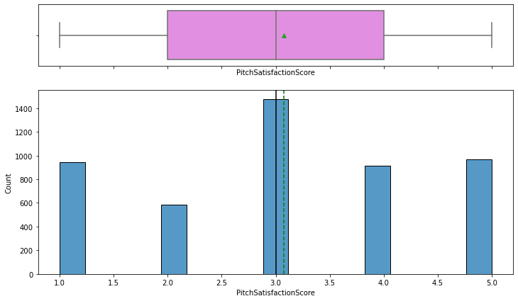

```python
# View Distribution of Numeric variable Monthly Income
histogram_boxplot(data, "PitchSatisfactionScore")
```

```python
#Find Mean Pitch score per ProdTaken (Look for values above and below 3)
data.groupby(['ProdTaken'])['PitchSatisfactionScore'].mean()
```

```
ProdTaken
0    3.044355
1    3.223913
Name: PitchSatisfactionScore, dtype: float64
```

```python
data.groupby(['ProdTaken'])['PitchSatisfactionScore'].value_counts()
```

```
ProdTaken  PitchSatisfactionScore
0          3                         1162
           1                          798
           5                          760
           4                          750
           2                          498
1          3                          316
           5                          210
           4                          162
           1                          144
           2                           88
Name: PitchSatisfactionScore, dtype: int64
```

```python
data.groupby(['ProdTaken'])['PitchSatisfactionScore'].value_counts(normalize = True)*100
```

```
ProdTaken  PitchSatisfactionScore
0          3                         29.284274
           1                         20.110887
           5                         19.153226
           4                         18.901210
           2                         12.550403
1          3                         34.347826
           5                         22.826087
           4                         17.608696
           1                         15.652174
           2                          9.565217
Name: PitchSatisfactionScore, dtype: float64
```

```python
data.groupby(['PitchSatisfactionScore'])['ProdTaken'].value_counts(normalize = True)*100
```

```
PitchSatisfactionScore  ProdTaken
1                       0            84.713376
                        1            15.286624
2                       0            84.982935
                        1            15.017065
3                       0            78.619756
                        1            21.380244
4                       0            82.236842
                        1            17.763158
5                       0            78.350515
                        1            21.649485
Name: ProdTaken, dtype: float64
```

```python
data.groupby(['ProductPitched'])['PitchSatisfactionScore'].mean()
```

```
ProductPitched
Basic           3.081433
Deluxe          3.006928
King            3.226087
Standard        3.061995
Super Deluxe    3.356725
Name: PitchSatisfactionScore, dtype: float64
```

#### Variable 'ProductPitched' Analysis

Note: Product Pitch analysis has been conducted while analysing other variable

```python
data['ProductPitched'].value_counts(normalize = True)*100
```

```
Basic           37.684124
Deluxe          35.433715
Standard        15.180033
Super Deluxe     6.996727
King             4.705401
Name: ProductPitched, dtype: float64
```

```python
data.groupby(['ProductPitched'])['ProdTaken'].value_counts()
```

```
ProductPitched  ProdTaken
Basic           0            1290
                1             552
Deluxe          0            1528
                1             204
King            0             210
                1              20
Standard        0             618
                1             124
Super Deluxe    0             322
                1              20
Name: ProdTaken, dtype: int64
```

```python
data.groupby(['ProductPitched'])['ProdTaken'].value_counts(normalize = True)*100
```

```
ProductPitched  ProdTaken
Basic           0            70.032573
                1            29.967427
Deluxe          0            88.221709
                1            11.778291
King            0            91.304348
                1             8.695652
Standard        0            83.288410
                1            16.711590
Super Deluxe    0            94.152047
                1             5.847953
Name: ProdTaken, dtype: float64
```

#### Insights - Product Pitched

- Products pitched by percentage: Basic: 38%, Deluxe:35%, Standard: 15%, Super Deluxe: 7%, King: 5%
- When ProductPitch:ProdTaken ratio - Basic:30%; Deluxe:12%; King:9%; Standard:17%; Super Deluxe: 6%